# M358K Project

## Introduction

With a large dataset of 189 files, I will be analyzing the Net Sales of the coffee shop I work at. I will also be using Facebook's decomposable time-series model to perform forecasting, and to evaluate trends. Since the data I have has strong seasonality due to the shop following the school-year, this method of forecasting will be very precise.

We begin with importing the necessary libraries and proceed to data cleaning. **(Feel free to skip to the "Time to Plot!" section)**

```python
import pandas as pd
import numpy as np
import matplotlib.pyplot as plt
import seaborn as sns
```

```python
final = pd.read_csv("tctrlm_20150824-20150828-sales-by-item.csv")
```

```python
final.head()
```

|  | Item Description | Department | Category | Quantity Sold | Sales Amount | Quantity Returned | Returns Amount | Costs | Discounts | Margin | Gross Profit | Net Sales | Quantity on Hand | Supplier | Supplier Code | Product UUID |
| --- | --- | --- | --- | --- | --- | --- | --- | --- | --- | --- | --- | --- | --- | --- | --- | --- |
| 0 | Coffee | Drinks | Coffee-SelfServe | 798.0 | 1574.45 | 0.0 | 0.0 | 630.42 | 11.89 | 59.65 | 932.14 | 1562.56 | 0.0 | Coffee Traders | NaN | 4A1C8F9B-EA7B-4D32-8942-7C32EB564416 |
| 1 | Tacodeli | Food | Tacos | 307.0 | 807.41 | 0.0 | 0.0 | 491.20 | 0.00 | 39.16 | 316.21 | 807.41 | 0.0 | Tacodeli | NaN | A116236F-E370-4B2C-B525-2A950558A450 |
| 2 | Latte | Drinks | Coffee | 235.0 | 867.85 | 0.0 | 0.0 | 256.15 | 45.04 | 68.87 | 566.66 | 822.81 | 0.0 | Coffee Traders | NaN | BCCA0CE6-6F45-4C70-8FD5-1D37108B2A69 |
| 3 | Americano | Drinks | Coffee | 193.0 | 483.10 | 0.0 | 0.0 | 162.12 | 12.59 | 65.54 | 308.39 | 470.51 | 0.0 | Coffee Traders | NaN | AA662F4A-E08C-4FCD-AC69-C6E1260D2711 |
| 4 | Cold Brew | Drinks | Coffee | 151.0 | 491.72 | 0.0 | 0.0 | 264.25 | 17.30 | 44.30 | 210.17 | 474.42 | 0.0 | Coffee Traders | NaN | 42426EB3-859F-4679-A916-57ABE5B5BFCC |

```python
final.columns
```

```
Index(['Item Description', 'Department', 'Category', 'Quantity Sold',
       'Sales Amount', 'Quantity Returned', 'Returns Amount', 'Costs',
       'Discounts', 'Margin', 'Gross Profit', 'Net Sales', 'Quantity on Hand',
       'Supplier', 'Supplier Code', 'Product UUID'],
      dtype='object')
```

## Data Cleaning

We begin cleaning the data (189 csv files) in order to create one large dataframe of our data.

```python
import os
file_arr = []

for root, dirs, files in os.walk("."):
    for filename in files:
        file_arr.append(filename)

file_arr.pop(0)
file_arr.pop(0)

file_arr.pop(-2)
```

```
'M358K Project-checkpoint.ipynb'
```

```python
file_arr.pop(-1)
```

```
'tctrlm_20160829-20160902-sales-by-item.csv'
```

```python
file_arr[0:10]
```

```
['tctrlm_20150831-20150904-sales-by-item.csv',
 'tctrlm_20150907-20150911-sales-by-item.csv',
 'tctrlm_20150914-20150918-sales-by-item.csv',
 'tctrlm_20150921-20150925-sales-by-item.csv',
 'tctrlm_20150928-20151002-sales-by-item.csv',
 'tctrlm_20151005-20151009-sales-by-item.csv',
 'tctrlm_20151012-20151016-sales-by-item.csv',
 'tctrlm_20151019-20151023-sales-by-item.csv',
 'tctrlm_20151026-20151030-sales-by-item.csv',
 'tctrlm_20151109-20151113-sales-by-item.csv']
```

```python
cleaned_date = []

def dateCleaner(arr):
    for item in arr:
        rawDate = item.split("_")[1].split("-")[0]
        year = rawDate[0:4]
        month = rawDate[4:6]
        day = rawDate[-2:]

        finalDate = month + "-" + day + "-" + year
        cleaned_date.append(finalDate)

dateCleaner(file_arr)
```

Now we add a date column at the end.

```python
final['Date'] = '08-24-2015'
final.head()
```

|  | Item Description | Department | Category | Quantity Sold | Sales Amount | Quantity Returned | Returns Amount | Costs | Discounts | Margin | Gross Profit | Net Sales | Quantity on Hand | Supplier | Supplier Code | Product UUID | Date |
| --- | --- | --- | --- | --- | --- | --- | --- | --- | --- | --- | --- | --- | --- | --- | --- | --- | --- |
| 0 | Coffee | Drinks | Coffee-SelfServe | 798.0 | 1574.45 | 0.0 | 0.0 | 630.42 | 11.89 | 59.65 | 932.14 | 1562.56 | 0.0 | Coffee Traders | NaN | 4A1C8F9B-EA7B-4D32-8942-7C32EB564416 | 08-24-2015 |
| 1 | Tacodeli | Food | Tacos | 307.0 | 807.41 | 0.0 | 0.0 | 491.20 | 0.00 | 39.16 | 316.21 | 807.41 | 0.0 | Tacodeli | NaN | A116236F-E370-4B2C-B525-2A950558A450 | 08-24-2015 |
| 2 | Latte | Drinks | Coffee | 235.0 | 867.85 | 0.0 | 0.0 | 256.15 | 45.04 | 68.87 | 566.66 | 822.81 | 0.0 | Coffee Traders | NaN | BCCA0CE6-6F45-4C70-8FD5-1D37108B2A69 | 08-24-2015 |
| 3 | Americano | Drinks | Coffee | 193.0 | 483.10 | 0.0 | 0.0 | 162.12 | 12.59 | 65.54 | 308.39 | 470.51 | 0.0 | Coffee Traders | NaN | AA662F4A-E08C-4FCD-AC69-C6E1260D2711 | 08-24-2015 |
| 4 | Cold Brew | Drinks | Coffee | 151.0 | 491.72 | 0.0 | 0.0 | 264.25 | 17.30 | 44.30 | 210.17 | 474.42 | 0.0 | Coffee Traders | NaN | 42426EB3-859F-4679-A916-57ABE5B5BFCC | 08-24-2015 |

## Data Merging

Merging all CSV files into one, to be able to compile easily.

```python
def df_merger(main_df):

    frames = [main_df]

    #read in the files one by one and clean them up
    for i in range(0, len(file_arr)):
        df = pd.read_csv(file_arr[i])
        df['Date'] = cleaned_date[i]
        frames.append(df)

    final = pd.concat(frames)

    return final

df = df_merger(final)
```

```python
df['Date'] = pd.to_datetime(df['Date'])

df.sort_values(by="Date")
```

|  | Item Description | Department | Category | Quantity Sold | Sales Amount | Quantity Returned | Returns Amount | Costs | Discounts | Margin | Gross Profit | Net Sales | Quantity on Hand | Supplier | Supplier Code | Product UUID | Date |
| --- | --- | --- | --- | --- | --- | --- | --- | --- | --- | --- | --- | --- | --- | --- | --- | --- | --- |
| 0 | Coffee | Drinks | Coffee-SelfServe | 798.0 | 1574.45 | 0.0 | 0.0 | 630.42 | 11.89 | 59.65 | 932.14 | 1562.56 | 0.0 | Coffee Traders | NaN | 4A1C8F9B-EA7B-4D32-8942-7C32EB564416 | 2015-08-24 |
| 25 | LaCroix | Drinks | Retail | 33.0 | 30.84 | 0.0 | 0.0 | 11.88 | 0.42 | 60.95 | 18.54 | 30.42 | 0.0 | UNFI | NaN | 97D1581F-9FE2-45F4-97E2-26D89F14FD2E | 2015-08-24 |
| 26 | Cappuccino | Drinks | Coffee | 32.0 | 97.95 | 0.0 | 0.0 | 29.76 | 15.90 | 63.73 | 52.29 | 82.05 | 0.0 | Coffee Traders | NaN | 780CBA1F-A7E2-4D18-9E49-71DD3E1DB27E | 2015-08-24 |
| 27 | Macchiato | Drinks | Coffee | 31.0 | 66.35 | 0.0 | 0.0 | 22.01 | 0.00 | 66.83 | 44.34 | 66.35 | 0.0 | Coffee Traders | NaN | 2CF07F9F-6130-41D8-9E0C-485446D6F4DE | 2015-08-24 |
| 28 | Milk | Drinks | Coffee | 29.0 | 78.35 | 0.0 | 0.0 | 23.78 | 0.00 | 69.65 | 54.57 | 78.35 | 0.0 | Oak Farms | NaN | 76E9EA05-EFD1-499A-A83C-6D89D92A58ED | 2015-08-24 |
| ... | ... | ... | ... | ... | ... | ... | ... | ... | ... | ... | ... | ... | ... | ... | ... | ... | ... |
| 1 | Cold Brew | Drinks | Coffee | 25.0 | 93.40 | 0.0 | 0.0 | 43.75 | 0.00 | 53.16 | 49.65 | 93.40 | 0.0 | Coffee Traders | NaN | 42426EB3-859F-4679-A916-57ABE5B5BFCC | 2019-08-19 |
| 0 | Coffee | Drinks | Coffee-SelfServe | 41.0 | 84.10 | 0.0 | 0.0 | 32.39 | 0.00 | 61.49 | 51.71 | 84.10 | 0.0 | Coffee Traders | NaN | 4A1C8F9B-EA7B-4D32-8942-7C32EB564416 | 2019-08-19 |
| 26 | Iced Tea | Drinks | Tea | 1.0 | 1.85 | 0.0 | 0.0 | 0.00 | 0.00 | 100.00 | 1.85 | 1.85 | 0.0 | Coffee Traders | NaN | FF735152-F62A-4D2F-9C4F-B4195BF7BF33 | 2019-08-19 |
| 12 | Cortado | Drinks | Coffee | 2.0 | 5.54 | 0.0 | 0.0 | 0.00 | 0.00 | 100.00 | 5.54 | 5.54 | 0.0 | not tracked | NaN | 4BB54C85-9CDD-464C-9142-8BB4970F920D | 2019-08-19 |
| 27 | Odwalla | Drinks | Retail | 1.0 | 3.80 | 0.0 | 0.0 | 2.47 | 0.00 | 35.00 | 1.33 | 3.80 | 0.0 | UNFI | NaN | 99B03279-ACC0-4AC8-83F9-1AB6F0F3F089 | 2019-08-19 |

11126 rows × 17 columns

```python
grouped_df = df.groupby("Date").sum().reset_index()
```

```python
grouped_df
```

|  | Date | Quantity Sold | Sales Amount | Quantity Returned | Returns Amount | Costs | Discounts | Margin | Gross Profit | Net Sales | Quantity on Hand | Supplier Code |
| --- | --- | --- | --- | --- | --- | --- | --- | --- | --- | --- | --- | --- |
| 0 | 2015-08-24 | 3362.0 | 8254.18 | 0.0 | 0.00 | 3256.71 | 137.84 | 2912.67 | 4859.63 | 8116.34 | 0.0 | 0.0 |
| 1 | 2015-08-31 | 5740.0 | 14802.46 | 9.0 | -23.52 | 6228.25 | 202.25 | 3185.24 | 8348.44 | 14576.69 | 0.0 | 0.0 |
| 2 | 2015-09-07 | 4786.0 | 12423.74 | 0.0 | 0.00 | 5276.09 | 168.29 | 3121.34 | 6979.36 | 12255.45 | 0.0 | 0.0 |
| 3 | 2015-09-14 | 6423.0 | 16549.90 | 7.0 | -14.59 | 6992.41 | 217.41 | 3013.16 | 9325.49 | 16317.90 | 0.0 | 0.0 |
| 4 | 2015-09-21 | 6341.0 | 16395.20 | 7.0 | -19.69 | 6764.27 | 260.08 | 3102.36 | 9351.16 | 16115.43 | 0.0 | 0.0 |
| ... | ... | ... | ... | ... | ... | ... | ... | ... | ... | ... | ... | ... |
| 184 | 2019-07-22 | 2285.0 | 6469.17 | 0.0 | 0.00 | 2085.65 | 154.78 | 5184.10 | 4228.74 | 6314.39 | -1146.0 | 0.0 |
| 185 | 2019-07-29 | 2116.0 | 6018.91 | 2.0 | -5.21 | 2005.43 | 162.17 | 5706.69 | 3846.10 | 5851.53 | -1146.0 | 0.0 |
| 186 | 2019-08-05 | 1977.0 | 5503.53 | 1.0 | -3.00 | 1871.46 | 138.99 | 5377.92 | 3490.08 | 5361.54 | -1146.0 | 0.0 |
| 187 | 2019-08-12 | 1914.0 | 5475.78 | 1.0 | -2.31 | 1839.98 | 116.79 | 4847.24 | 3516.70 | 5356.68 | -1146.0 | 0.0 |
| 188 | 2019-08-19 | 166.0 | 515.61 | 0.0 | 0.00 | 160.98 | 14.30 | 2115.44 | 340.33 | 501.31 | 0.0 | 0.0 |

189 rows × 12 columns

## Time to Plot!

We begin by setting out axis size and naming the axes.

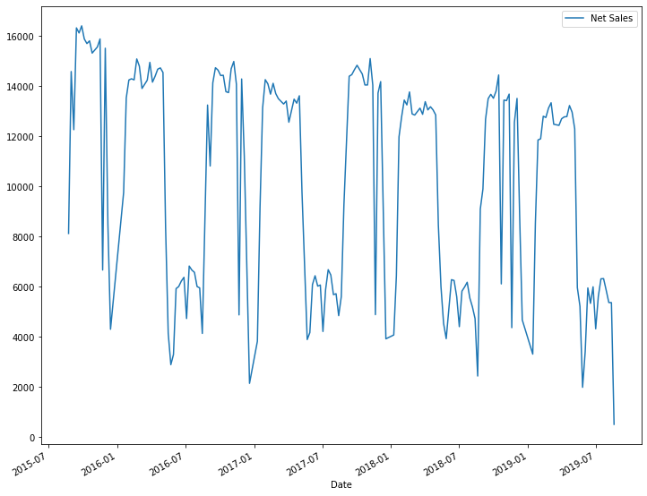

```python
fig, ax = plt.subplots(figsize=(12,10))

grouped_df.plot(x='Date', y='Net Sales', ax=ax)
```

## Forecasting

We begin out forecast using Facebook's Prophet library.

```python
from fbprophet import Prophet

prophet_df = grouped_df[['Date', 'Net Sales']]
prophet_df.columns = ['ds', 'y']

m = Prophet()
m.fit(prophet_df)
```

```
Importing plotly failed. Interactive plots will not work.
INFO:fbprophet:Disabling weekly seasonality. Run prophet with weekly_seasonality=True to override this.
INFO:fbprophet:Disabling daily seasonality. Run prophet with daily_seasonality=True to override this.
```

```
<fbprophet.forecaster.Prophet at 0x18dd91828b0>
```

```python
future = m.make_future_dataframe(periods=104, freq="W")
future.tail()
```

|  | ds |
| --- | --- |
| 288 | 2021-07-18 |
| 289 | 2021-07-25 |
| 290 | 2021-08-01 |
| 291 | 2021-08-08 |
| 292 | 2021-08-15 |

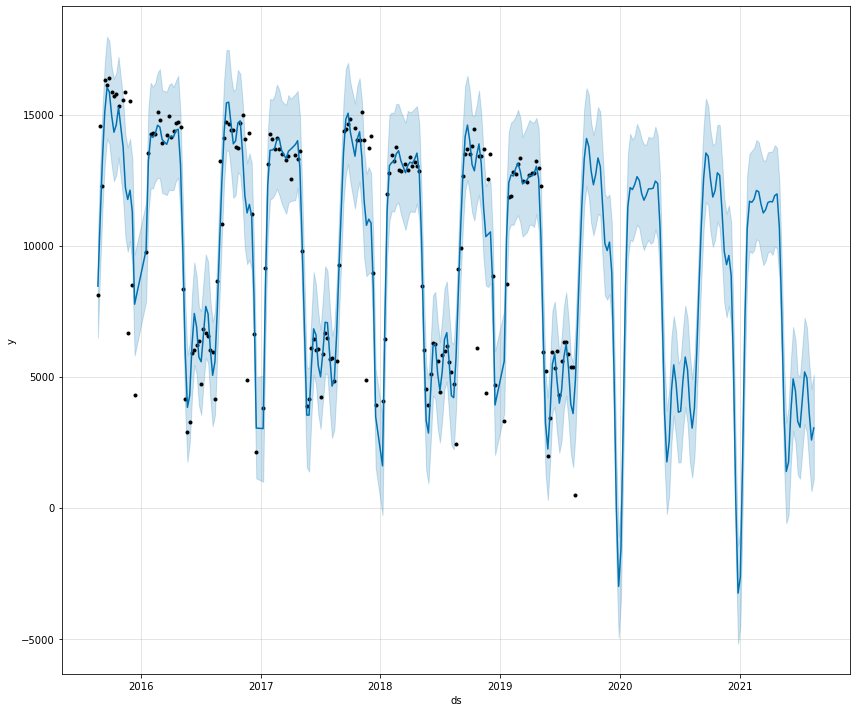

```python
forecast = m.predict(future)

fig,ax = plt.subplots(figsize=(12,10))
fig1 = m.plot(forecast, ax= ax)
```

## Interpretation

The blue background behind the lines is an 80% confidence interval. Once the black dots end, that is when the prediction begins. Visually, it seems we have a downward trend of Net Sales for this particular coffee shop.

Below, we analyze specifics.

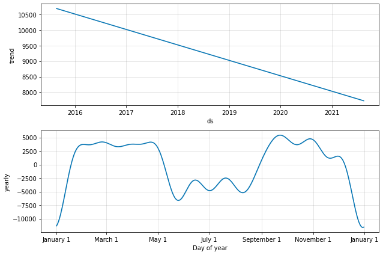

```python
fig2 = m.plot_components(forecast)
```

## Statistical Summary

Below is a statistical summary of our compiled dataset for Net Sales. Pay special attention to our mean and std (standard deviation).

```python
ns_summary = grouped_df['Net Sales']
ns_summary.describe()
```

```
count      189.000000
mean     10147.801111
std       4275.839028
min        501.310000
25%       5979.100000
50%      12472.530000
75%      13790.480000
max      16399.340000
Name: Net Sales, dtype: float64
```

## Categorical Analysis

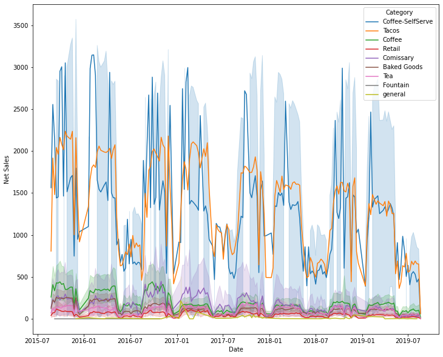

```python
fig, ax = plt.subplots(figsize=(12,10))

sns.lineplot(data=df, x='Date', y='Net Sales', hue='Category', ax=ax)
```

## Conclusion

Based on our analysis, this particular coffee shop is on a downward trend for Net Sales. This must be due to some outside source. Could it be the quality of the coffee? Could it be a decline in attendance? More people not drinking coffee? A Financial burden? Are more people making coffee at home?

There are many possibilities for this decline, and to determine these would be a task left to surveying. I would be interested to learn exactly what the cause is.